# Analysis of Time Series-An Introduction

```r
library(data.table)
library(here)
library(hms)
library(ggplot2)
library(grid)
library(gtable)
library(tseries)
library(TSstudio)
library(lubridate)
library(RtsaPkg)
library(RplotterPkg)

current_dir <- here::here("Analysis of Time Series-An Introduction")
```

Author: Rick Dean

Article date: 2020-12-22

Abstract

The following notes/scripts/plots are inspired by the book [The Analysis of Time Series: An Introduction](http://www.ams.sunysb.edu/~xing/tsRbook/index.html) by Chris Chatfield and Haipeng Xing

# Some Representative Time Series

## Classic Beveridge wheat price index series

1. Info on the classic Beveridge wheat price index series `tseries::bev`:

```r
data(bev, package = "tseries") # set the data

is.ts(bev)
```

```
## [1] TRUE
```

```r
length(bev)
```

```
## [1] 370
```

```r
head(bev, 10)
```

```
##  [1] 17 19 20 15 13 14 14 14 14 11
```

```r
head(stats::time(bev), 10)
```

```
##  [1] 1500 1501 1502 1503 1504 1505 1506 1507 1508 1509
```

```r
head(stats::cycle(bev), 10)
```

```
##  [1] 1 1 1 1 1 1 1 1 1 1
```

```r
stats::frequency(bev)
```

```
## [1] 1
```

```r
stats::deltat(bev)
```

```
## [1] 1
```

```r
stats::start(bev)
```

```
## [1] 1500    1
```

```r
stats::end(bev)
```

```
## [1] 1869    1
```

2. Summary of the `tseries::bev` data set:

```r
TSstudio::ts_info(bev)
```

```
##  The bev series is a ts object with 1 variable and 370 observations
##  Frequency: 1
##  Start time: 1500 1
##  End time: 1869 1
```

3. Convert the `tseries::bev` time series object (class = “ts”) to a data.frame/data.table:

```r
wheat_index_dt <- RtsaPkg::ts_to_df(bev, col_name = "PriceIdx")
str(wheat_index_dt)
```

```
## Classes 'data.table' and 'data.frame':   370 obs. of  2 variables:
##  $ PriceIdx: num  17 19 20 15 13 14 14 14 14 11 ...
##  $ DateTime: Date, format: "1500-01-01" "1501-01-01" ...
##  - attr(*, ".internal.selfref")=<externalptr>
```

4. Plot the Beveridge wheat price index series:

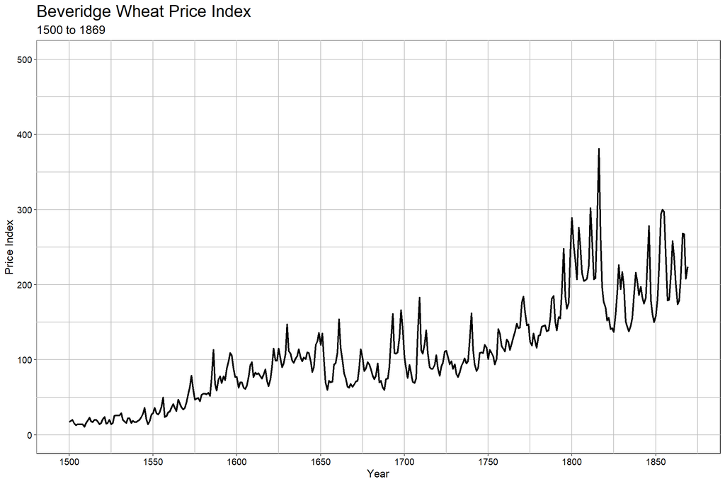

```r
RplotterPkg::create_scatter_plot(
    df = wheat_index_dt,
    aes_x = "DateTime",
    aes_y = "PriceIdx",
    title = "Beveridge Wheat Price Index",
    subtitle = "1500 to 1869",
    x_title = "Year",
    y_title = "Price Index",
    rot_y_tic_label = TRUE,
    pts_size = 0.7,
    pts_color = "purple",
    x_limits = as.Date(c("1499-01-01", "1870-01-01")),
    x_major_breaks = seq.Date(from = as.Date("1450-1-1"), to = as.Date("1900-1-1"), by = "50 year"),
    x_date_labels = "%Y",
    y_limits = c(0, 500),
    show_pts = FALSE,
    connect = TRUE
)
```

## Closing prices of S&P 500 index

```r
apath <- file.path(current_dir, "data", "sp500_1995-2016.csv")
s_p_500_dt <- data.table::fread(apath)
str(s_p_500_dt)
```

```
## Classes 'data.table' and 'data.frame':   5539 obs. of  2 variables:
##  $ Date  : chr  "1/4/95" "1/5/95" "1/6/95" "1/9/95" ...
##  $ Return: num  0.377 -0.0675 0.0727 0.045 0.1851 ...
##  - attr(*, ".internal.selfref")=<externalptr>
```

2. Convert `Date` variable from character to date type.

```r
s_p_500_dt[, Date_alt := as.Date(Date, format = "%m/%d/%y")]
str(s_p_500_dt)
```

```
## Classes 'data.table' and 'data.frame':   5539 obs. of  3 variables:
##  $ Date    : chr  "1/4/95" "1/5/95" "1/6/95" "1/9/95" ...
##  $ Return  : num  0.377 -0.0675 0.0727 0.045 0.1851 ...
##  $ Date_alt: Date, format: "1995-01-04" "1995-01-05" ...
##  - attr(*, ".internal.selfref")=<externalptr>
```

3. Plot the series:

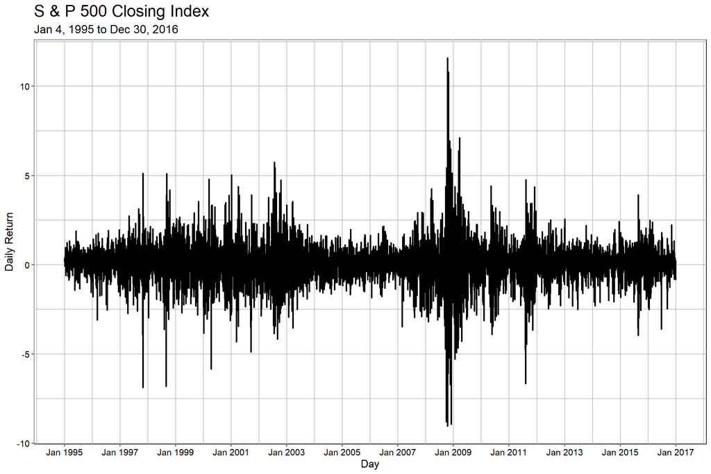

```r
RplotterPkg::create_scatter_plot(
    df = s_p_500_dt,
    aes_x = "Date_alt",
    aes_y = "Return",
    x_limits = as.Date(c("1995-01-01", "2017-01-01")),
    x_major_date_breaks = "2 year",
    x_date_labels = "%b %Y",
    title = "S & P 500 Closing Index",
    subtitle = "Jan 4, 1995 to Dec 30, 2016",
    x_title = "Day",
    y_title = "Daily Return",
    rot_y_tic_label = TRUE,
    pts_size = 0.7,
    pts_color = "purple",
    show_pts = FALSE,
    connect = TRUE
)
```

## Air temperature in Anchorage, Alaska

```r
apath <- file.path(current_dir, "data", "alaska_temp_1951-2016.csv")
alaska_temps_dt <- data.table::fread(apath)
str(alaska_temps_dt)
```

```
## Classes 'data.table' and 'data.frame':   792 obs. of  2 variables:
##  $ Date   : int  195101 195102 195103 195104 195105 195106 195107 195108 195109 195110 ...
##  $ Celsius: num  -21.7 -16.6 -16.8 -3 4.3 9.3 11.8 10.3 5.1 -4.4 ...
##  - attr(*, ".internal.selfref")=<externalptr>
```

2. Convert the `Date` variable to a Date variable:

```r
alaska_temps_dt[, Date_alt := paste(substring(as.character(Date), 1, 4), substring(as.character(Date), 5, 6), "01", sep = "-")]
alaska_temps_dt[, Date_alt := as.Date(Date_alt)]
str(alaska_temps_dt)
```

```
## Classes 'data.table' and 'data.frame':   792 obs. of  3 variables:
##  $ Date    : int  195101 195102 195103 195104 195105 195106 195107 195108 195109 195110 ...
##  $ Celsius : num  -21.7 -16.6 -16.8 -3 4.3 9.3 11.8 10.3 5.1 -4.4 ...
##  $ Date_alt: Date, format: "1951-01-01" "1951-02-01" ...
##  - attr(*, ".internal.selfref")=<externalptr>
```

3. Plot the Alaska temperatures starting in 2001:

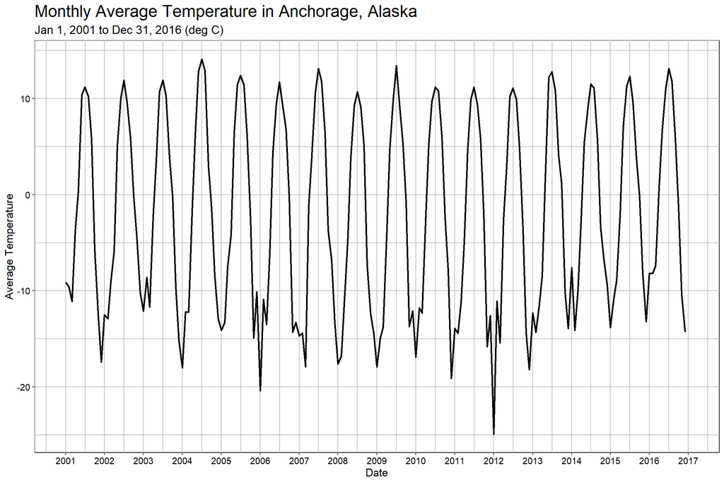

```r
RplotterPkg::create_scatter_plot(
  df = alaska_temps_dt,
  aes_x = "Date_alt",
  aes_y = "Celsius",
  title = "Monthly Average Temperature in Anchorage, Alaska",
  subtitle = "Jan 1, 2001 to Dec 31, 2016 (deg C)",
  x_title = "Date",
  y_title = "Average Temperature",
  rot_y_tic_label = TRUE,
  pts_size = 0.7,
  pts_color = "purple",
  x_limits = as.Date(c("2001-01-01", "2016-12-31")),
  x_major_date_breaks = "1 year",
  x_date_labels = "%Y",
  show_pts = FALSE,
  connect = TRUE
)
```

## Domestic sales of Australian wine

1. Read the csv file of Australian wine in successive quarters from March 1985 to June 2014:

```r
apath <- file.path(current_dir, "data", "aus_wine_sales.csv")
wine_sales_dt <- data.table::fread(apath)
str(wine_sales_dt)
```

```
## Classes 'data.table' and 'data.frame':   118 obs. of  2 variables:
##  $ V1: chr  "Mar-1985" "Jun-1985" "Sep-1985" "Dec-1985" ...
##  $ V2: int  7006 10516 11089 9637 6448 9642 11593 9426 5826 9398 ...
##  - attr(*, ".internal.selfref")=<externalptr>
```

2. Rename the variables:

```r
wine_sales_dt <- wine_sales_dt[, .(DateChr = V1, Sales = V2)]
str(wine_sales_dt)
```

```
## Classes 'data.table' and 'data.frame':   118 obs. of  2 variables:
##  $ DateChr: chr  "Mar-1985" "Jun-1985" "Sep-1985" "Dec-1985" ...
##  $ Sales  : int  7006 10516 11089 9637 6448 9642 11593 9426 5826 9398 ...
##  - attr(*, ".internal.selfref")=<externalptr>
```

3. Add a `Date` type column:

```r
wine_sales_dt[, Date_alt := paste(substring(DateChr, 5, 8), substring(DateChr, 1, 3), "01", sep = "-")]
wine_sales_dt[, Date_alt := as.Date(Date_alt, format = "%Y-%b-%d")]
str(wine_sales_dt)
```

```
## Classes 'data.table' and 'data.frame':   118 obs. of  3 variables:
##  $ DateChr : chr  "Mar-1985" "Jun-1985" "Sep-1985" "Dec-1985" ...
##  $ Sales   : int  7006 10516 11089 9637 6448 9642 11593 9426 5826 9398 ...
##  $ Date_alt: Date, format: "1985-03-01" "1985-06-01" ...
##  - attr(*, ".internal.selfref")=<externalptr>
```

3. Plot the wine sales:

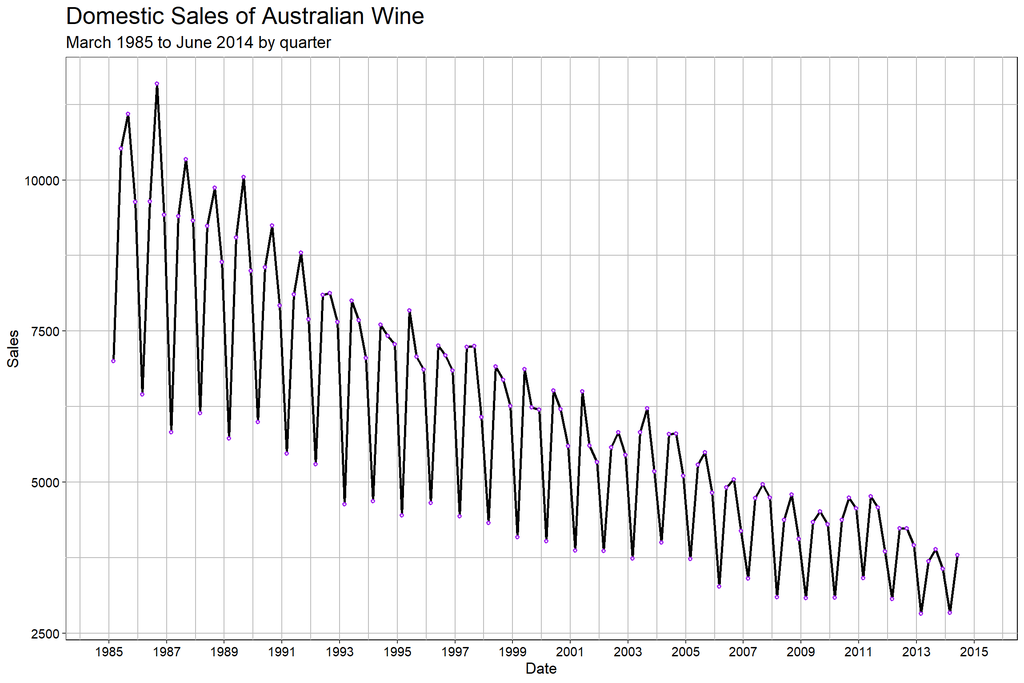

```r
RplotterPkg::create_scatter_plot(
  df = wine_sales_dt,
  aes_x = "Date_alt",
  aes_y = "Sales",
  title = "Domestic Sales of Australian Wine",
  subtitle = "March 1985 to June 2014 by quarter",
  x_title = "Date",
  rot_y_tic_label = TRUE,
  pts_size = 0.7,
  pts_color = "purple",
  x_limits = as.Date(c("1985-01-01", "2015-01-01")),
  x_major_date_breaks = "2 year",
  x_date_labels = "%Y",
  connect = TRUE
)
```

## Total population and birth rate for the US

```r
apath <- file.path(current_dir, "data", "US_pop_birthrate.csv")
birth_pop_dt <- data.table::fread(apath)
str(birth_pop_dt)
```

```
## Classes 'data.table' and 'data.frame':   56 obs. of  3 variables:
##  $ DATE              : chr  "1/1/60" "1/1/61" "1/1/62" "1/1/63" ...
##  $ populaton         : int  180671000 183691000 186538000 189242000 191889000 194303000 196560000 198712000 200706000 202677000 ...
##  $ birthrate(per1000): num  23.7 23.3 22.4 21.7 21.1 19.4 18.4 17.8 17.6 17.9 ...
##  - attr(*, ".internal.selfref")=<externalptr>
```

2. Rename variables:

```r
birth_pop_dt <-  birth_pop_dt[, .(DateChr = DATE, Population = populaton, BirthRate = `birthrate(per1000)`)]
str(birth_pop_dt)
```

```
## Classes 'data.table' and 'data.frame':   56 obs. of  3 variables:
##  $ DateChr   : chr  "1/1/60" "1/1/61" "1/1/62" "1/1/63" ...
##  $ Population: int  180671000 183691000 186538000 189242000 191889000 194303000 196560000 198712000 200706000 202677000 ...
##  $ BirthRate : num  23.7 23.3 22.4 21.7 21.1 19.4 18.4 17.8 17.6 17.9 ...
##  - attr(*, ".internal.selfref")=<externalptr>
```

3. Add a `Date` type:

```r
birth_pop_dt[,`:=`(Year_alt = lubridate::parse_date_time2(DateChr, "m/d/y", cutoff_2000 = 16L), Population = Population/10000000)]
str(birth_pop_dt)
```

```
## Classes 'data.table' and 'data.frame':   56 obs. of  4 variables:
##  $ DateChr   : chr  "1/1/60" "1/1/61" "1/1/62" "1/1/63" ...
##  $ Population: num  18.1 18.4 18.7 18.9 19.2 ...
##  $ BirthRate : num  23.7 23.3 22.4 21.7 21.1 19.4 18.4 17.8 17.6 17.9 ...
##  $ Year_alt  : POSIXct, format: "1960-01-01" "1961-01-01" ...
##  - attr(*, ".internal.selfref")=<externalptr>
```

4. Put the series into a “long” form where *Population* and *BirthRate* are separate observations:

```r
birth_pop_dt <- data.table::melt(birth_pop_dt, measure.vars = c("Population", "BirthRate"), variable.name = "Measure", value.name = "Value")
str(birth_pop_dt)
```

```
## Classes 'data.table' and 'data.frame':   112 obs. of  4 variables:
##  $ DateChr : chr  "1/1/60" "1/1/61" "1/1/62" "1/1/63" ...
##  $ Year_alt: POSIXct, format: "1960-01-01" "1961-01-01" ...
##  $ Measure : Factor w/ 2 levels "Population","BirthRate": 1 1 1 1 1 1 1 1 1 1 ...
##  $ Value   : num  18.1 18.4 18.7 18.9 19.2 ...
##  - attr(*, ".internal.selfref")=<externalptr>
```

4. Create separate plots for *BirthRate* and *Population* across *Year_alt*:

[figure not shown]

```r
plot_birth_pop <- RplotterPkg::multi_scatter_plot(
  df = birth_pop_dt,
  factor_var = "Measure",
  factor_x = "Year_alt",
  columns = 1,
  aes_y = "Value",
  title = "Total Yearly BirthRate/Population for the US",
  subtitle = "(Pop x 10 million) 1960 to 2015",
  x_title = "Year",
  y_titles = c("Rate", "Pop"),
  rot_y_tic_label = TRUE,
  pts_color = "violet",
  pts_fill = "blue",
  pts_size = 0.7,
  x_major_breaks = seq(from = as.POSIXct("1960-01-01"), to = as.POSIXct("2016-12-31"), by = "4 year"),
  x_date_labels = "%Y",
  show_pts = FALSE,
  connect = TRUE,
  row_height = 3,
  col_width = 11
)
```

## Prices and volumes of IBM stocks

1. Read the transaction prices and volumes of IBM stocks:

```r
apath <- file.path(current_dir, "data", "taq_trade_ibm_100104.txt")
ibm_trade_dt <- data.table::fread(apath)
str(ibm_trade_dt)
```

```
## Classes 'data.table' and 'data.frame':   30680 obs. of  7 variables:
##  $ V1: chr  "8:00:00" "8:01:13" "8:01:21" "8:01:24" ...
##  $ V2: num  132 131 131 131 131 ...
##  $ V3: int  0 0 0 0 0 0 0 0 0 0 ...
##  $ V4: int  0 0 0 0 0 0 0 0 0 0 ...
##  $ V5: chr  "T" "F" "F" "T" ...
##  $ V6: chr  "P" "T" "T" "P" ...
##  $ V7: int  100 100 200 100 100 100 136 100 100 200 ...
##  - attr(*, ".internal.selfref")=<externalptr>
```

2. Rename columns:

```r
ibm_trade_dt <- ibm_trade_dt[, .(Time = V1, Price = V2, G127 = V3, Corr = V4, Cond = V5, Ex = V6, Size = V7)]
str(ibm_trade_dt)
```

```
## Classes 'data.table' and 'data.frame':   30680 obs. of  7 variables:
##  $ Time : chr  "8:00:00" "8:01:13" "8:01:21" "8:01:24" ...
##  $ Price: num  132 131 131 131 131 ...
##  $ G127 : int  0 0 0 0 0 0 0 0 0 0 ...
##  $ Corr : int  0 0 0 0 0 0 0 0 0 0 ...
##  $ Cond : chr  "T" "F" "F" "T" ...
##  $ Ex   : chr  "P" "T" "T" "P" ...
##  $ Size : int  100 100 200 100 100 100 136 100 100 200 ...
##  - attr(*, ".internal.selfref")=<externalptr>
```

3. Convert the time:

```r
ibm_trade_dt[, `:=`(Time_alt = hms::as_hms(Time), Size = Size/10)]
str(ibm_trade_dt)
```

```
## Classes 'data.table' and 'data.frame':   30680 obs. of  8 variables:
##  $ Time    : chr  "8:00:00" "8:01:13" "8:01:21" "8:01:24" ...
##  $ Price   : num  132 131 131 131 131 ...
##  $ G127    : int  0 0 0 0 0 0 0 0 0 0 ...
##  $ Corr    : int  0 0 0 0 0 0 0 0 0 0 ...
##  $ Cond    : chr  "T" "F" "F" "T" ...
##  $ Ex      : chr  "P" "T" "T" "P" ...
##  $ Size    : num  10 10 20 10 10 10 13.6 10 10 20 ...
##  $ Time_alt: 'hms' num  08:00:00 08:01:13 08:01:21 08:01:24 ...
##   ..- attr(*, "units")= chr "secs"
##  - attr(*, ".internal.selfref")=<externalptr>
```

4. Filter the time for 3 minutes between 09:35:00 to 09:38:00:

```r
ibm_trade_3min_dt <- ibm_trade_dt[Time_alt > as_hms("09:35:00") & Time_alt < as_hms("09:38:00")]
str(ibm_trade_3min_dt)
```

```
## Classes 'data.table' and 'data.frame':   895 obs. of  8 variables:
##  $ Time    : chr  "9:35:01" "9:35:01" "9:35:01" "9:35:01" ...
##  $ Price   : num  132 132 132 132 132 ...
##  $ G127    : int  0 0 0 0 0 0 0 0 0 0 ...
##  $ Corr    : int  0 0 0 0 0 0 0 0 0 0 ...
##  $ Cond    : chr  "@" "@" "@" "F" ...
##  $ Ex      : chr  "Z" "N" "N" "N" ...
##  $ Size    : num  10 20 10 10 10 10 10 10 10 10 ...
##  $ Time_alt: 'hms' num  09:35:01 09:35:01 09:35:01 09:35:01 ...
##   ..- attr(*, "units")= chr "secs"
##  - attr(*, ".internal.selfref")=<externalptr>
```

5. Separate plots of *Price* and *Size*:

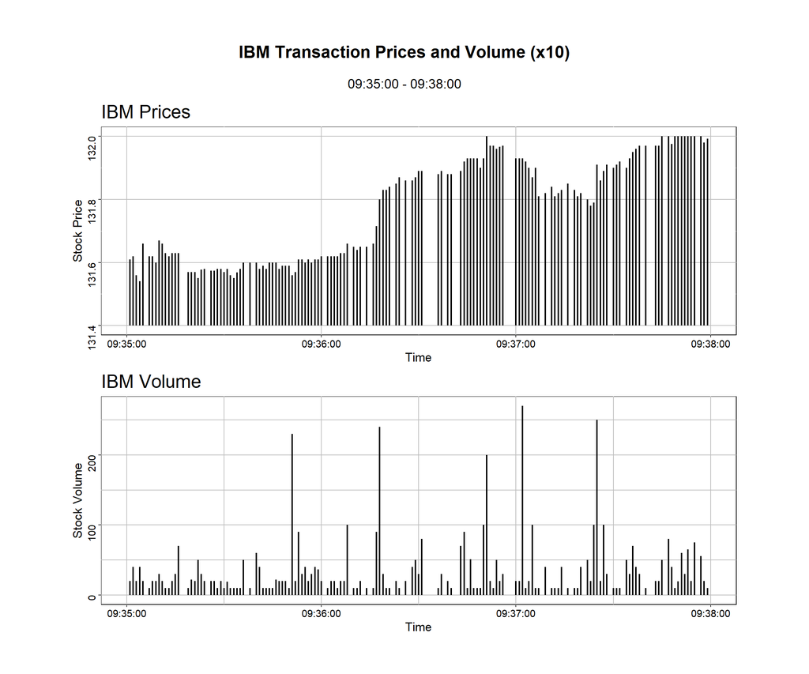

```r
price_plot <- RplotterPkg::create_stick_plot(
  df = ibm_trade_3min_dt,
  base_val = 131.4,
  aes_x = "Time_alt",
  aes_y = "Price",
  title = "IBM Prices",
  x_title = "Time",
  y_title = "Stock Price",
  y_limits = c(131.4, 132),
  y_major_breaks = seq(131.4,132,0.2),
  show_minor_grids = FALSE,
  x_date_labels = "%H-%M-%S"
)
volume_plot <- RplotterPkg::create_stick_plot(
  df = ibm_trade_3min_dt,
  aes_x = "Time_alt",
  aes_y = "Size",
  title = "IBM Volume",
  x_title = "Time",
  y_title = "Stock Volume",
  x_date_labels = "%H-%M-%S"
)

layout <- list(
  plots = list(price_plot, volume_plot),
  rows = c(1,2),
  cols = c(1,1)
)

stock_plot <- RplotterPkg::multi_panel_grid(
  layout = layout,
  col_widths = 10,
  row_heights = c(4,4),
  title = "IBM Transaction Prices and Volume (x10)",
  subtitle = "09:35:00 - 09:38:00",
)
```